# Mapas no R com ggmap

Este tutorial mostra como adicionar uma ‘camada base’ ou fundo aos seus mapas de ggplot.

## Informação espacial armazenada em data frames - pontos no google maps

Vamos começar a trabalhar com mapas a partir de um exemplo que, veremos, utilizará as ferramentas que aprendemos até então para produzir nossos primeiros mapas. Para tanto, vamos utilizar o cadastro de escolas que a Prefeitura Municipal de São Paulo disponibiliza [aqui](http://dados.prefeitura.sp.gov.br/).

Nossa primeira tarefa é baixar os dados e faremos isso de forma inteligente e sem “cliques”. A partir do url do arquivo do cadastro, que guardaremos no objeto “url_cadatros_escolas”, faremos o download do arquivo e guardaremos o arquivo .csv baixado como o nome “temp.csv”:

```r
library(tidyverse)
url_cadatros_escolas <- "http://dados.prefeitura.sp.gov.br/dataset/8da55b0e-b385-4b54-9296-d0000014ddd5/resource/39db5031-7238-4139-bcaa-e620a3180188/download/escolasr34fev2017.csv"
download.file(url_cadatros_escolas, "temp.csv")
```

Veja que baixar o arquivo diretamente no R é preferível ao processo manual, pois podemos rapidamente reproduzir o processo, além de documentá-lo. Vamos abrir o arquivo:

```r
escolas <- read_delim("temp.csv", delim = ";")
```

Explore o arquivo com o comando *glimpse*:

```r
glimpse(escolas)
```

```
## Observations: 5,324
## Variables: 51
## $ DRE         <chr> "G", "FO", "MP", "BT", "PJ", "BT", "FO", "JT", "JT...
## $ CODESC      <chr> "000086", "000094", "000108", "000191", "000205", ...
## $ TIPOESC     <chr> "EMEI", "EMEI", "EMEF", "EMEF", "EMEBS", "EMEI", "...
## $ NOMESC      <chr> "PAULO CAMILHIER FLORENCANO", "VICENTE PAULO DA SI...
## $ DIRETORIA   <chr> "GUAIANASES", "FREGUESIA/BRASILANDIA", "SAO MIGUEL...
## $ SUBPREF     <chr> "GUAIANASES", "CASA VERDE/CACHOEIRINHA", "SAO MIGU...
## $ CEU         <chr> NA, NA, NA, NA, NA, NA, NA, NA, NA, NA, NA, NA, NA...
## $ ENDERECO    <chr> "RUA FELICIANO DE MENDON\xc7A", "RUA DOUTOR FLEURY...
## $ NUMERO      <chr> "502", "295", "159", "140", "206", "90", "51", "34...
## $ BAIRRO      <chr> "JARDIM S\xc3O PAULO(ZONA LESTE)", "VILA SANTA MAR...
## $ CEP         <chr> "08460365", "02563010", "08090290", "05742100", "0...
## $ TEL1        <chr> "25578348", "39813227", "25865294", "58450121", "3...
## $ TEL2        <chr> "25571947", NA, "25811484", NA, "39067229", NA, NA...
```

[output cut: 38 more lines]

Não há nada de extraordinário no arquivo, que se assemelha aos que vimos até então. Há, porém, uma dupla de variáveis que nos permite trabalhar “geograficamente” com o dado: LATITUDE e LONGITUDE. “Lat e Long” são a informação fundamental de um dos sistemas de coordenadas (coordinate reference system, CRS) mais utilizados para localização de objetos na superfície da terra.

```r
emef <- escolas  %>%
  rename(lat = LATITUDE, lon = LONGITUDE, tipo = TIPOESC) %>%
  mutate(lat = lat / 1000000,
         lon = lon / 1000000,
         ano = as.numeric(substr(DT_INI_FUNC, 7, 10))) %>%
  filter(tipo == "EMEF")
```

Pronto! Temos agora uma informação geográfica das EMEFs e uma variável de interesse – ano – que utilizaremos para investigar a expansão da rede.

Para analisar estes dados como dados espaciais precisamos dizer a R quais são as variáveis de localização e transformá-lo em um objeto ‘simple features’ usando o biblioteca *sf* e a função *st_as_sf* para criar um objeto tipo “simple features”. Lembre-se de instalar o pacote antes de carregá-lo.

```r
library(sf)
emef <- emef %>% st_as_sf(coords=c("lon","lat"), crs=4326)
```

Vamos construir um primeiro mapa, usando a função que conhecemos – ggplot – a partir das informações de latitude e longitude das escolas:

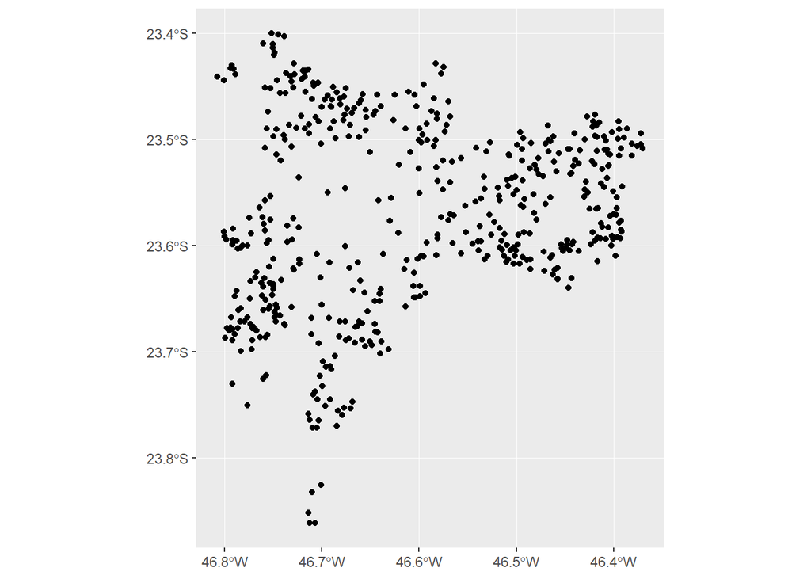

```r
emef %>% ggplot() +
  geom_sf()
```

Veja que podemos “imaginar” o formato da cidade de São Paulo com os pontos, mas o mapa não é propriamente um mapa. Falta uma “camada” básica, sobre a qual os pontos serão desenhados.

Vamos utilizar o pacote *ggmap*, que é um pacote para visualização de dados espaciais com o pacote *ggplot2* para obter tal “camada”. Com a função *get_map*, faremos o download de um mapa que servirá de base para os pontos das EMEFs.

Por padrão, utilizaríamos a função *get_map*, que retorna um mapa de “terreno” e utiliza a API da Google, com zoom e escala automáticos. No entanto, a Google trocou os termos de uso da API e agora é necessário ter uma conta, informar o número do cartão de crédito e fazer autenticação via R. Por esta razão, vamos utilizamos a API ‘stamen’, que utiliza a função *get_stamenmap* em vez de *get_map*

```r
library(ggmap)
bbox_sp <- c(left = -46.869803,
             bottom = -23.774462,
             right = -46.4417181,
             top = -23.3921176)
```

Com as coordenadas da cidade, vamos obter um mapa de São Paulo:

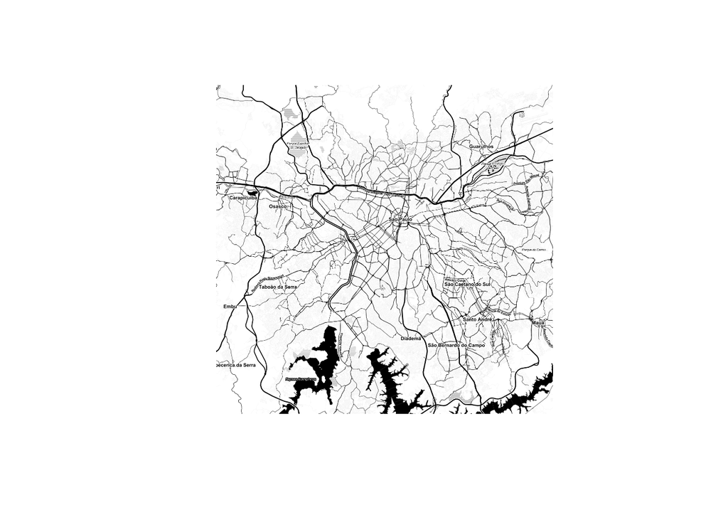

```r
map_sp <- map_sp <- get_stamenmap(bbox_sp, zoom = 12, maptype = "toner")
plot(map_sp)
```

Antes de alterar estes argumentos, vamos utilizar uma função “irmã” à *ggplot*, *ggmap*, para juntar o mapa de São Paulo com os pontos das escolas:

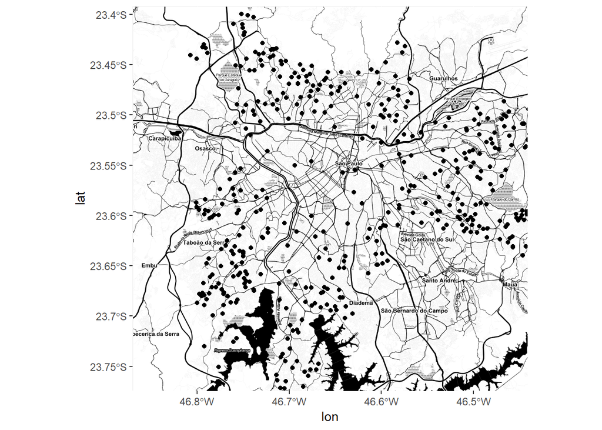

```r
ggmap(map_sp) +
  geom_sf(data = emef, inherit.aes=F)
```

Feio ainda, porém bastante mais informativo. Veja que combinamos duas fontes de dados: o cadastro da PMSP e um mapa obtido na API da Stamen.

Agora, vamos usar uma informação sobre as escolas para diferenciar os pontos. Os dados do cadastro não trazem informações muito interessantes sobre a escola e por isso utilizaremos o ano de criação. Em nosso desafio seguinte trabalharemos com informações sobre a escola que vêm de outra base do mesmo portal da prefeitura.

Introduziremos em nosso mapa uma escala de cores para diferenciar as EMEFs por ano de criação:

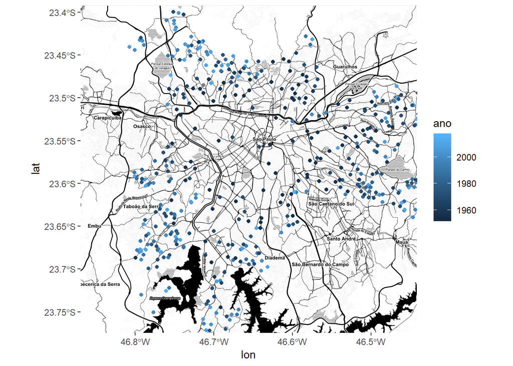

```r
ggmap(map_sp) +
  geom_sf(data = emef, inherit.aes=F, aes(color=ano))
```

Como era de se esperar, os pontos mais claros na cidade estão nos extremos e as EMEFs mais antigas, e geral, nos bairros que consolidaram mais cedo no processo de urbanização.